# Paper: Zero-Adjusted Birnbaum-Saunders regression model

Vera Tomazella, Juvêncio S. Nobre, Gustavo, H.A. Pereira and Manoel Santos-Neto

August 14, 2018

# 1 Application

## 1.1 R packages

```r
library(gamlss.nl)
library(RBS)
library(ggplot2)
library(ssym)
```

## 1.2 Data

In this application, the data set considered is the biaxial fatigue data analyzed by Rieck and Nedelman (1991), Lemonte and Cordeiro (2011), Lemonte and Patriota (n.d.), Vanegas, Rondon, and Cysneiros (2012) and Lemonte, Cordeiro, and Moreno-Arenas (2016). This data set has 46 observations and consists of lifes of a metal piece subjected to cyclic stretching and compressing, where the response variable $N$ denotes the number of cycles to failure of the metal specimen and the explanatory variable $W$ is the work per cycle ($mj/m^3$). Here, we use the response variable on a reduced scale to facilitate the estimation procedure, i.e., $Y \times 100 \equiv N$.

```r
data("Biaxial", package="ssym")
N <- Biaxial$Life
N <- N/100;N
```

```
##  [1] 32.80 50.46 15.63 47.07  9.77 28.34 22.66 22.08 10.40  7.00 15.83
## [12]  4.82  8.04 10.93 11.25  8.84 13.00  8.52  5.80 10.66 11.14  3.86
## [23]  7.45  7.36  7.50  3.16  4.56  5.52  3.55  2.42  1.90  1.27  1.85
## [34]  2.55  1.95  2.83  2.12  3.27  3.73  1.25  1.87  1.35  2.45  1.37
## [45]  2.00  1.90
```

```r
W <- Biaxial$Work;W
```

```
##  [1]  11.5  13.0  14.3  15.6  16.0  17.3  19.3  21.1  21.5  22.6  22.6
## [12]  24.0  24.0  24.6  25.2  25.5  26.3  27.9  28.3  28.4  28.6  30.9
## [23]  31.9  34.5  40.1  40.1  43.0  44.1  46.5  47.3  48.7  52.9  56.6
## [34]  59.9  60.2  60.3  60.5  62.1  62.8  66.5  67.0  67.1  67.9  68.8
## [45]  75.4 100.5
```

## 1.3 RBS nonlinear regression model

Therefore, we fit a RBS nonlinear regression model
$$\mu_i = \beta_1 \textrm{e}^{\frac{\beta_2}{w_i}}, \quad i=1,\ldots,46,$$
where $Y_i \sim \text{RBS}(\mu_i,\sigma)$. The adjustment was performed using the function **nlgamlss()** of the package **gamlss.nl** whose objective is to allow nonlinear fitting within a GAMLSS model. The estimates and standard errors obtained were

```r
mod1 <- nlgamlss(y=N,mu.fo=~p1*exp(p2/W),sigma.formula = ~1,mu.start =c(1,40),sigma.start =1,family = RBS(mu.link = "identity",sigma.link = "identity"))
mod1$converged
```

```
## [1] 1
```

```r
summary(mod1)
```

```
## Family:  c("RBS", "BirnbaumSaunders")
##
## Call:  nlgamlss(y = N, mu.fo = ~p1 * exp(p2/W), sigma.formula = ~1,
##     mu.start = c(1, 40), sigma.start = 1, family = RBS(mu.link = "identity",
##         sigma.link = "identity"))
##
## Fitting method: "JL()"
##
## -------------------------------------------------------------------
## Mu link function:  identity
## Mu Coefficients:
##     Estimate  Std. Error  t-value    p-value
## p1     1.276      0.1719    7.423  1.148e-13
## p2    47.957      3.4411   13.936  3.812e-44
##
## -------------------------------------------------------------------
## Sigma link function:  identity
## Migma Coefficients:
##              Estimate  Std. Error  t-value    p-value
## (Intercept)     9.814       2.048    4.792  1.651e-06
##
## -------------------------------------------------------------------
## No. of observations in the fit:  46
## Degrees of Freedom for the fit:  3
##       Residual Deg. of Freedom:  43
##                       at cycle:  22
##
## Global Deviance:     214.695
##             AIC:     220.695
##             SBC:     226.1809
```

Figure 1.1 shows the QQ-plot with simulated envelope of quantile residuals and the scatter plot with the fitted model. Figures 1.1(a) and 1.2 are used to verify the distribution assumption of the model and they do not show unusual features. Note that, in Figure 1.1(b), the fitted line (proposed model) has a good agreement with the real data.

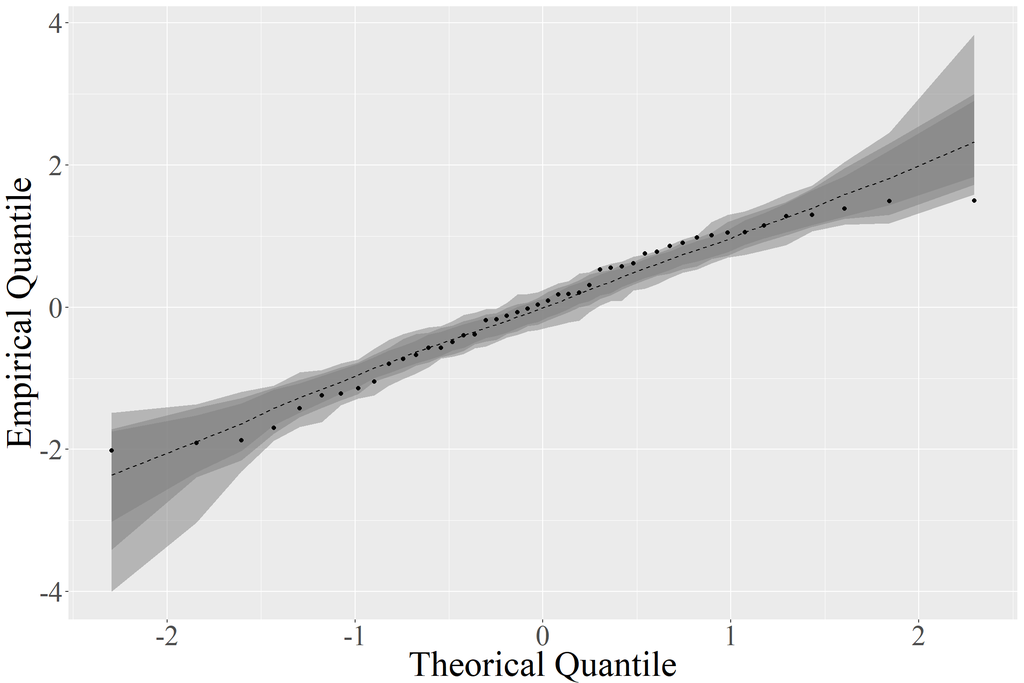

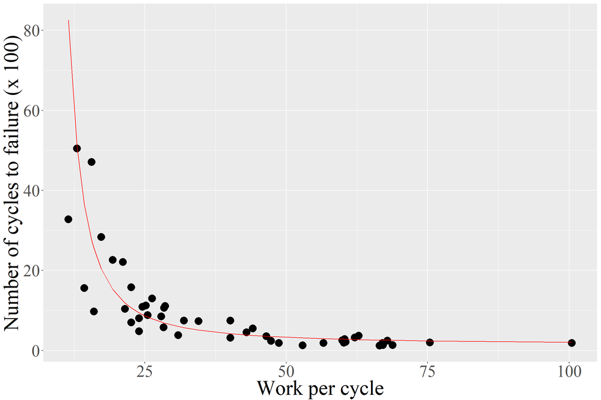

Figure 1.1: QQ-plot with simulated envelope of quantile residuals (a) and scatter-plot with fitted model (b).

```r
set.seed(13171619)
envelope.nlrbs(mod1,k=100)
df <- data.frame(N=N,W=W,fv=mod1$mu.fv)
ggplot(df,aes(W,N)) + geom_point(size=5) + geom_line(aes(W,fv),col=2)+ xlab("Work per cycle") + ylab("Number of cycles to failure (x 100)")+ theme(text=element_text(size=30,family="serif"))
```

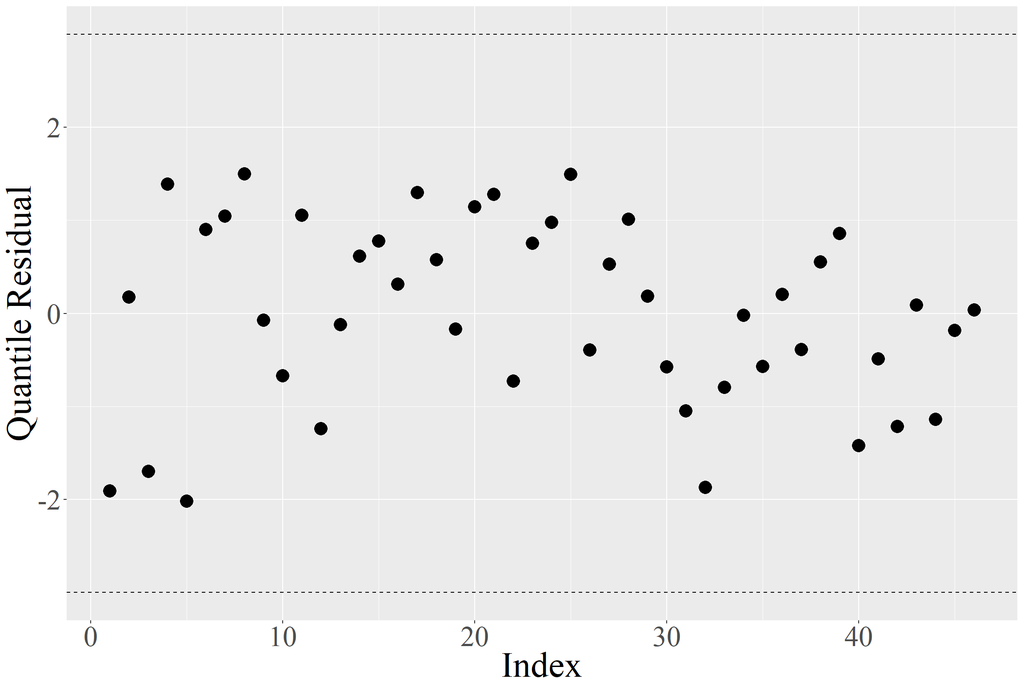

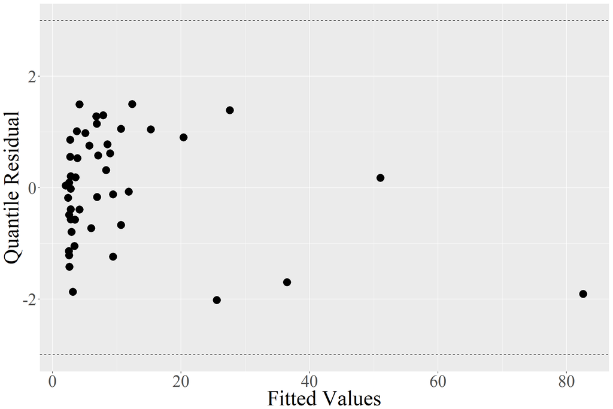

Figure 1.2: Residuals plots.

```r
df<- data.frame(res=mod1$residuals,ind=1:mod1$N,fv=mod1$mu.fv)
ggplot(df,aes(ind,res)) + geom_point(size=5) + geom_hline(yintercept = c(-3,3),lty=2) + xlab("Index") + ylab("Quantile Residual") + theme(text=element_text(size=30,family="serif"))
ggplot(df,aes(fv,res)) + geom_point(size=5) + geom_hline(yintercept = c(-3,3),lty=2)+ xlab("Fitted Values") + ylab("Quantile Residual") + theme(text=element_text(size=30,family="serif"))
```

Infuence diagnostics for the nonlinear BS regression model are presented in Figure 1.3. Figure 1.3 displays index plots of $\mathrm{C}_i$ and $|\mathbf{d}_\text{max}|$, from where observation #1 is detected as potentially influential. Changes are not detected when the observation is removed.

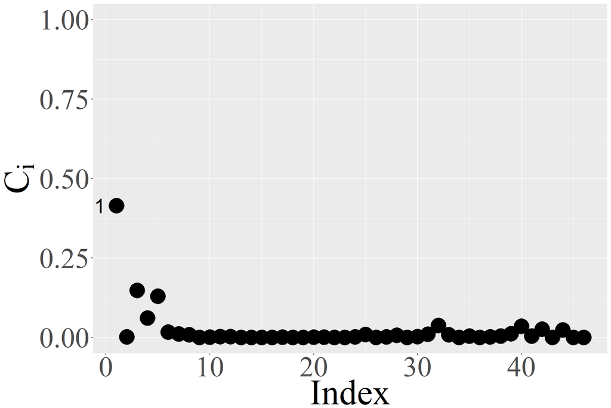

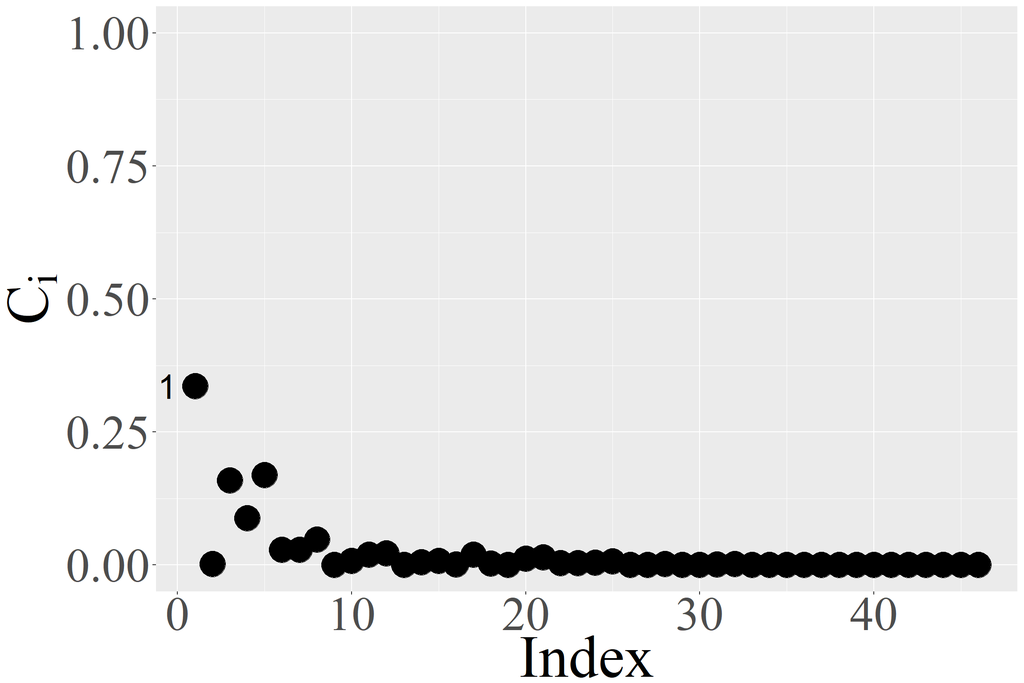

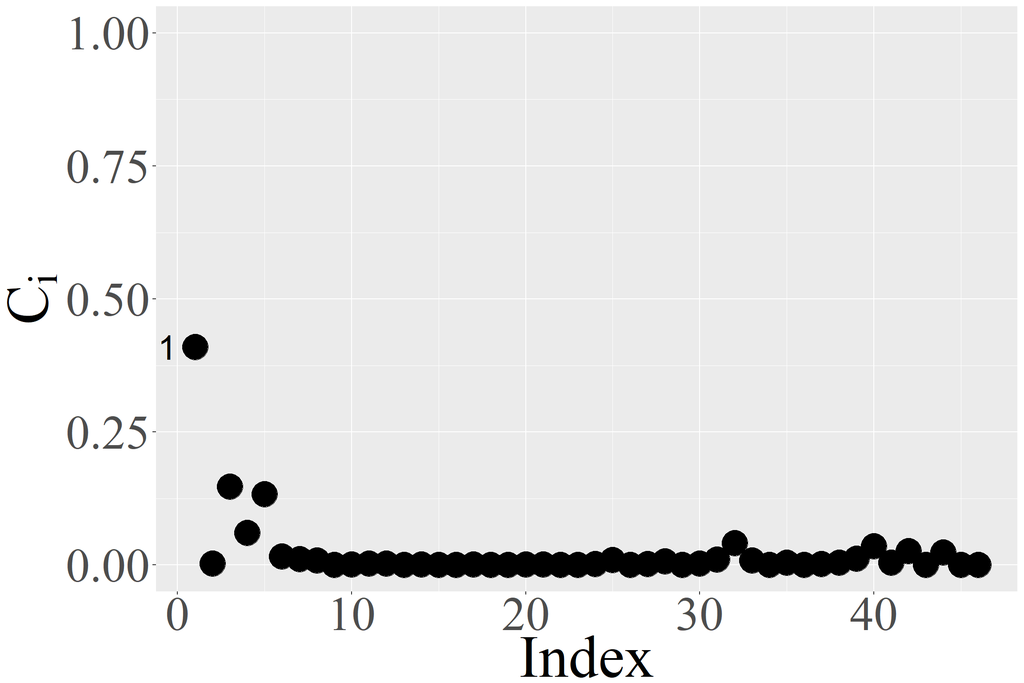

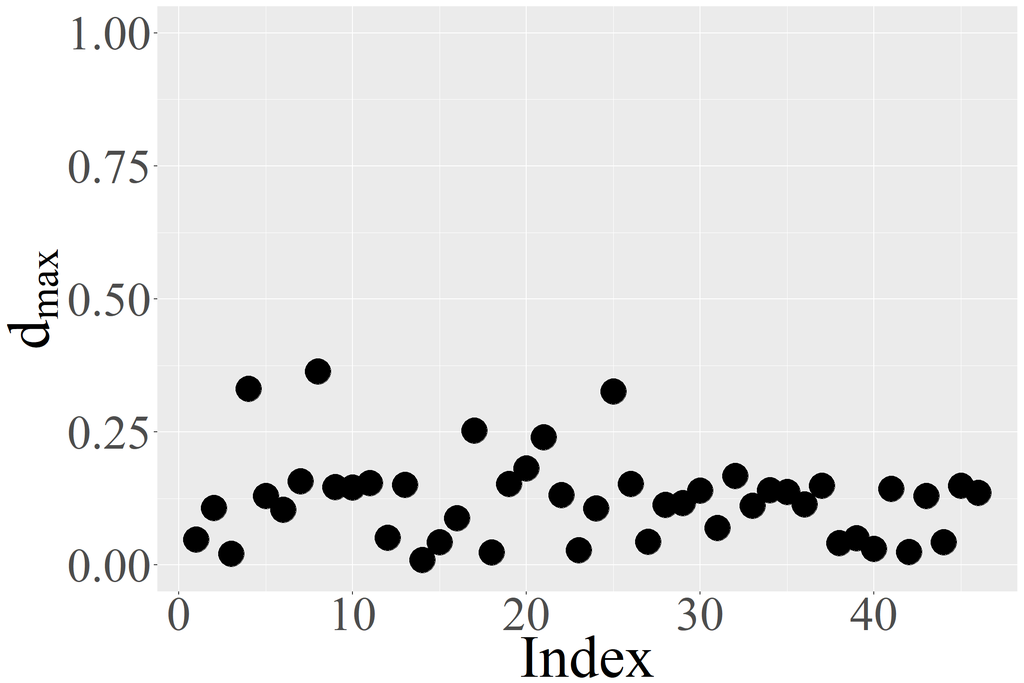

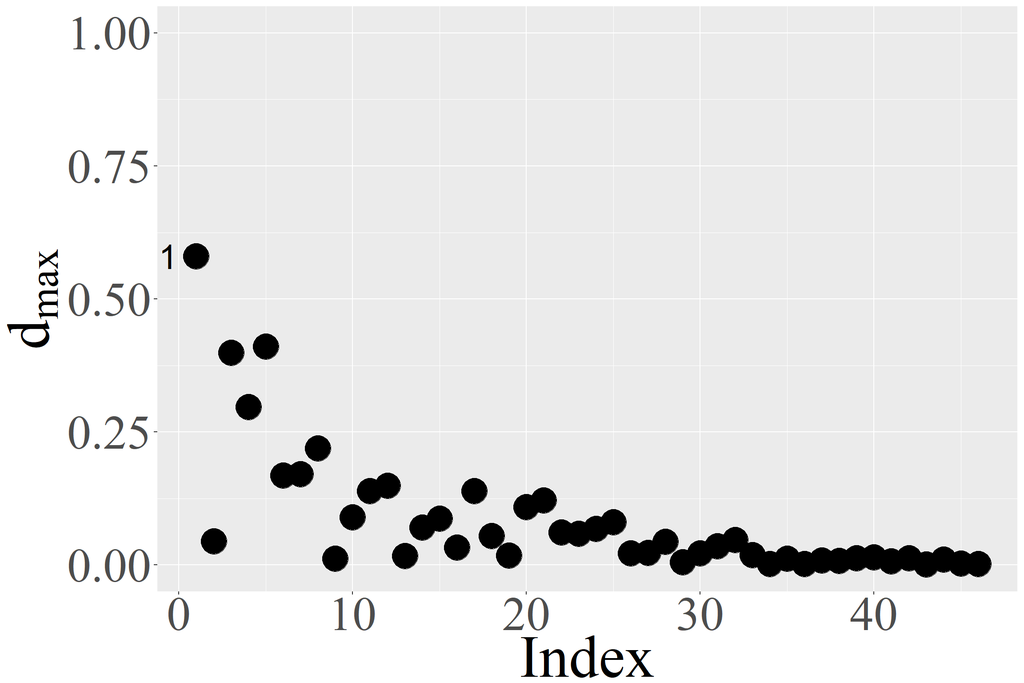

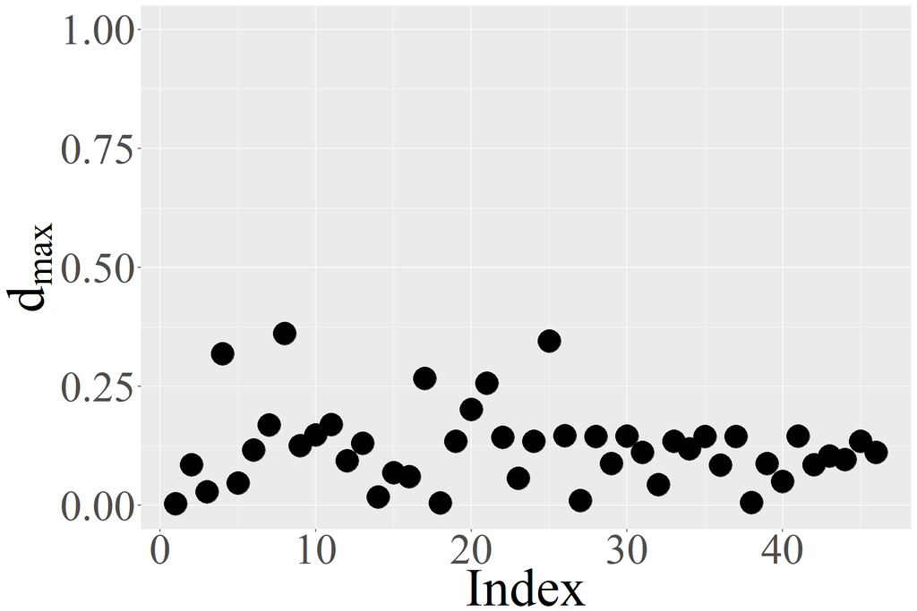

Figure 1.3: Index plots of C_i and d_{max}.

```r
  Cibeta <- local.infl$Ci.beta
  Cialpha <- local.infl$Ci.alpha
  Citheta <- local.infl$Ci.theta

  dmbeta <- local.infl$dmax.beta
  dmalpha <- local.infl$dmax.alpha
  dmtheta <- local.infl$dmax.theta

  index <- 1:length(Cibeta)
  CbxI <- data.frame(index,Cibeta,Cialpha,Citheta)
  CbxI. <- CbxI[c(1),]
  ggplot(CbxI,aes(index,Cibeta)) + geom_point(size=10)+ ylim(0,1) + geom_text(data=CbxI.,aes(index,Cibeta,label=index),hjust=2,size=10) + xlab("Index") + ylab(expression(C[i]))+ theme(text=element_text(size=50,family="serif"))
  ggplot(CbxI,aes(index,Cialpha)) + geom_point(size=10)+ ylim(0,1) + geom_text(data=CbxI.,aes(index,Cialpha,label=index),hjust=2,size=10) + xlab("Index") + ylab(expression(C[i]))+ theme(text=element_text(size=50,family="serif"))
  ggplot(CbxI,aes(index,Citheta)) + geom_point(size=10)+ ylim(0,1) + geom_text(data=CbxI.,aes(index,Citheta,label=index),hjust=2,size=10) + xlab("Index") + ylab(expression(C[i]))+ theme(text=element_text(size=50,family="serif"))

  I <- 1:length(dmbeta)
  dxI <- data.frame(I,dmbeta,dmalpha,dmtheta)
  dxI... <- dxI[c(1),]
  ggplot(CbxI,aes(I,dmbeta)) + geom_point(size=10)+ ylim(0,1)  + xlab("Index") + ylab(expression(d[max])) +  theme(text=element_text(size=50,family="serif"))
  ggplot(CbxI,aes(I,dmalpha)) + geom_point(size=10)+ ylim(0,1) + geom_text(data=dxI...,aes(I,dmalpha,label=I),hjust=2,size=10) + xlab("Index") + ylab(expression(d[max]))+ theme(text=element_text(size=50,family="serif"))
  ggplot(CbxI,aes(I,dmtheta)) + geom_point(size=10)+ ylim(0,1) + xlab("Index") + ylab(expression(d[max]))+ theme(text=element_text(size=50,family="serif"))
```

Finally, we have that the mean of the number of cycles ($\times 100$) to failure of the metal specimen can be described by $\hat \mu(w_i) = 1.276\times \textrm{e}^{\frac{47.957}{w_i}}$.

## References

Lemonte, A.J., and G.M. Cordeiro. 2011. “Birnbaum-Saunders nonlinear regression models.” *Journal of Statistical Computation and Simulation* 53: 4441–52.

Lemonte, Artur J., Gauss M. Cordeiro, and Germán Moreno-Arenas. 2016. “Improved Likelihood-Based Inference in Birnbaum–Saunders Nonlinear Regression Models.” *Applied Mathematical Modelling* 40 (19): 8185–8200.

Lemonte, Artur J., and Alexandre G. Patriota. n.d. “Influence Diagnostics in Birnbaum–Saunders Nonlinear Regression Models.” *Journal of Applied Statistics* 38 (5). Taylor & Francis: 871–84.

Rieck, J.R., and J.R. Nedelman. 1991. “A log-linear model for the Birnbaum-Saunders distribution.” *Technometrics* 3: 51–60.

Vanegas, L.H., L.M. Rondon, and F.J.A. Cysneiros. 2012. “Diagnostic procedures in Birnbaum-Saunders nonlinear regression models.” *Computational Statistics and Data Analysis* 56: 1662–80.